# p2_expo_David

Xingxing Tong

- Exploration for Recommend system

### Dataset:u.data

```r
suppressPackageStartupMessages({
   library(recommenderlab)
   library(dplyr)
   library(ggplot2)
   })
```

Basic Info. 1) 100,000 ratings (1-5) from 943 users on 1682 movies 2) Each user has rated at least 20 movies (>=20) 3) Simple demographic info for the users (age, gender, occupation, zip ->“maps” )

Survey: 7-month Sep.19,1997 - April 22,1998 This data has been cleaned up - users who had less than 20 ratings or did not have complete demographic information were removed from this data set.

Dataset

u.data – The full u data set, 100000 ratings by 943 users on 1682 items. Each user has rated at least 20 movies. Users and items are numbered consecutively from 1. The data is randomly ordered. This is a tab separated list of user id | item id | rating | timestamp. The time stamps are unix seconds since 1/1/1970 UTC

# CITATION

To acknowledge use of the dataset in publications, please cite the following paper:

F. Maxwell Harper and Joseph A. Konstan. 2015. The MovieLens Datasets: History and Context. ACM Transactions on Interactive Intelligent Systems (TiiS) 5, 4, Article 19 (December 2015), 19 pages. DOI=http://dx.doi.org/10.1145/2827872

```r
# udata<- read.table("http://files.grouplens.org/datasets/movielens/ml-100k/u.data")
# names(udata) <- c("User_id","Item_id","Rating","Timestamp")
# head(udata)

#delete Timestamp
#udata<-udata[,1:3]

# udata <- data.frame(udata)
# save(udata,file="udata.Rda")

# setwd("~/GitHub/P2_Recom_Sys_MovieLens/Exploration/David")

load("./data/udata.Rda")
```

```r
Unique_id <-unique(udata$User_id)

id_count<- function(id) {
  return(dim(udata[udata$User_id==id ,])[1])
}
#count how many lines for each unique Id
count_result<-sapply(X=Unique_id,FUN=id_count)
#summary the reuslts

table(count_result)
```

```
## count_result
##  20  21  22  23  24  25  26  27  28  29  30  31  32  33  34  35  36  37
##  32  24  23  21  21  16  19  16  15  12  14   8   9  16   8  11   8   8
##  38  39  40  41  42  43  44  45  46  47  48  49  50  51  52  53  54  55
##   9   8   7   8   8  10   8   5   7  12   6   6   5  12   3   9   6   6
##  56  57  58  59  60  61  62  63  64  65  66  67  68  69  70  71  72  73
##   6   8  10   6   3   2   7   6   7   6   6   4   5   2   3   7   2   4
##  74  75  76  77  78  79  80  81  82  83  84  85  86  87  89  90  92  93
##   4   8   4   2   1   3   4   5   2   3   2   1   3   2   4   2   2   5
##  94  95  96  97  98 100 101 102 103 104 105 106 107 108 109 110 111 112
##   1   2   2   2   5   3   3   5   2   4   4   4   6   4   4   3   2   3
## 113 114 115 117 118 119 120 121 122 123 124 125 126 127 128 129 130 131
##   1   2   4   1   3   1   3   6   2   1   4   1   1   4   2   2   1   2
## 132 133 134 135 136 137 138 139 140 141 142 143 145 146 147 148 149 150
##   2   4   1   5   2   3   2   2   2   2   3   3   2   2   4   3   4   4
```

[output cut: 18 more lines]

```r
#qplot()

count_result_df <- data.frame(count_result)
colnames(count_result_df)[1] <-"Numb_of_Movies"
count_result_df$id <- rownames(count_result_df)

movie_numb_median <- median(count_result_df$Numb_of_Movies)
# R.K the blue line indicates the median of count_result
p1 <-ggplot(count_result_df, aes(Numb_of_Movies)) +geom_histogram(binwidth = 3)+
        geom_vline(xintercept = movie_numb_median,colour="steelblue",linetype = "longdash")+
        ggtitle("Histogram of movie counts(bw=3)")

#ggsave("./image/week7_hist.png",plot=p1)

#divide users into two groups:
#Movie lovers: rating numb. in [20,65]  Movie enthusiasts: rating numb. in [66,737]

#Movie lovers
u_id_1<-count_result_df[count_result_df$Numb_of_Movies<66,]$id
#Movie enthusiasts
u_id_2<-count_result_df[count_result_df$Numb_of_Movies>65,]$id
```

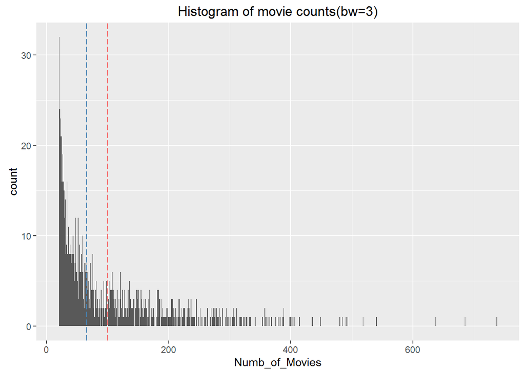

```r
ggplot(count_result_df, aes(Numb_of_Movies)) +geom_histogram(binwidth = 1)+
        geom_vline(xintercept = movie_numb_median,colour="steelblue",linetype = "longdash")+
        geom_vline(xintercept = 100,colour="red",linetype = "longdash")+
        ggtitle("Histogram of movie counts(bw=3)")
```

## Movie

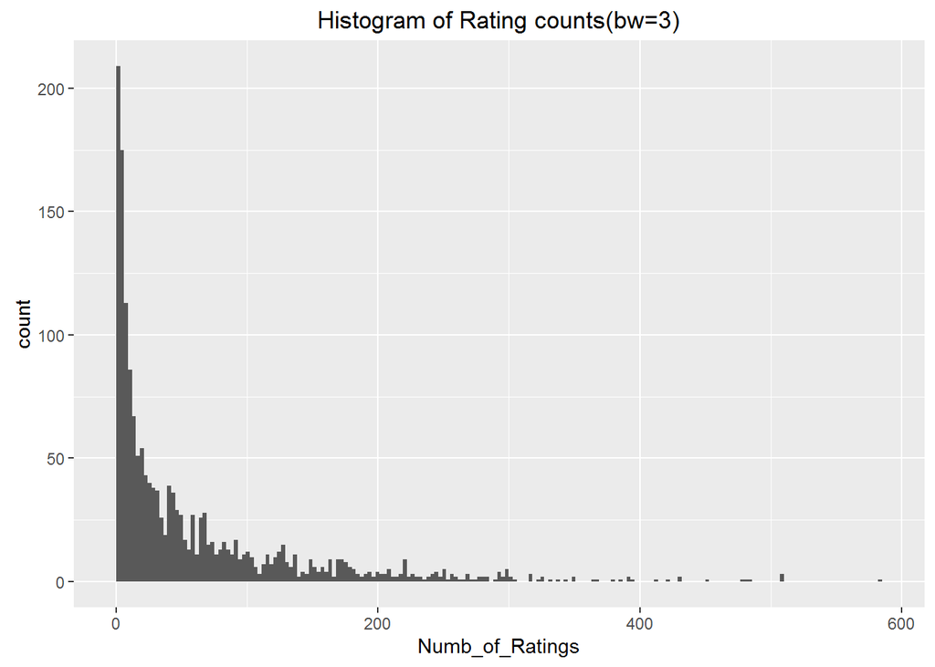

```r
Unique_Mid <-unique(udata$Item_id)
id_Mcount<- function(id) {
  return(dim(udata[udata$Item_id==id ,])[1])
}

count_Mresult<-sapply(X=Unique_Mid,FUN=id_Mcount)

count_Mresult_df <- data.frame(count_Mresult)
colnames(count_Mresult_df)[1] <-"Numb_of_Ratings"
count_Mresult_df$ItemId <- 1:dim(count_Mresult_df)[1]

ggplot(count_Mresult_df, aes(Numb_of_Ratings)) +geom_histogram(binwidth = 3)+
        ggtitle("Histogram of Rating counts(bw=3)")
```

```r
reorder_countM<- count_Mresult_df[order(-count_Mresult_df$Numb_of_Ratings),]

#Top 100 popular Movies
countM_100<-reorder_countM[1:100,]

countM_100[100,]
```

```
##    Numb_of_Ratings ItemId
## 52             218     52
```

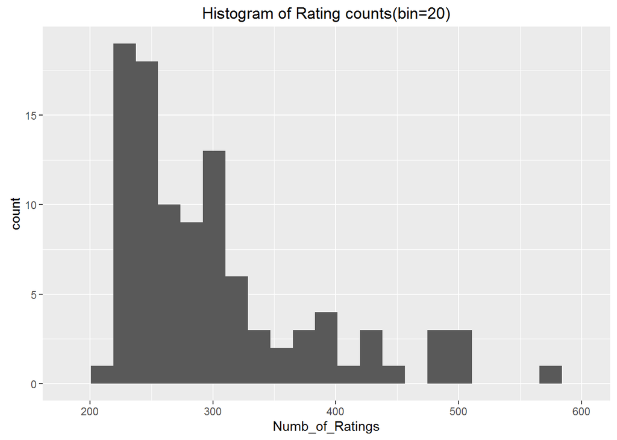

```r
#Movies in this list have at least 218 ratings.
ggplot(countM_100, aes(Numb_of_Ratings)) +geom_histogram(bins = 20)+
        ggtitle("Histogram of Rating counts(bin=20)")
```

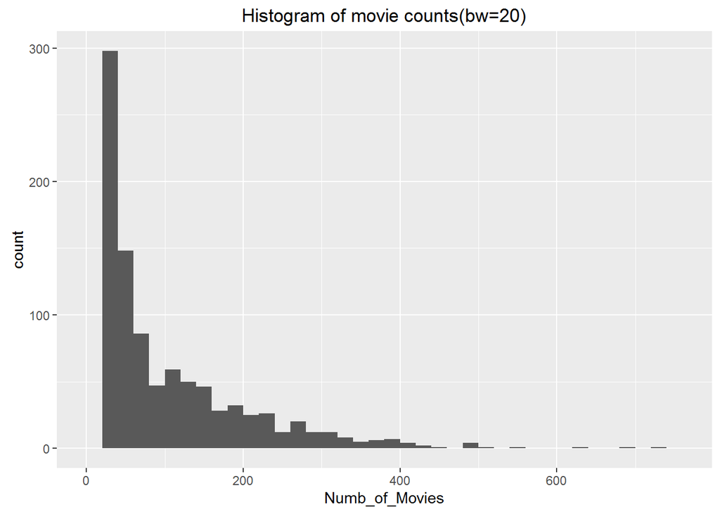

```r
#Top 100 popular Movies ID
MV_100Id<-countM_100$ItemId

#Find the users who rated these movies
User_M100 <- unique(udata[udata$Item_id==MV_100Id,]$User_id)

count_result<-sapply(X=User_M100,FUN=id_count)
newcount_result_df <- data.frame(count_result)
colnames(count_result_df)[1] <-"Numb_of_Movies"


ggplot(count_result_df, aes(Numb_of_Movies)) +geom_histogram(binwidth = 20)+
        ggtitle("Histogram of movie counts(bw=20)")
```